# Predicting earnings from census data

Anna Prades

Saturday, June 27, 2015

The United States government periodically collects demographic information by conducting a census. The file census.csv contains 1994 census data for 31,978 individuals in the United States.

The dataset includes the following 13 variables:

- age = the age of the individual in years
  - workclass = the classification of the individual’s working status (does the person work for the federal government, work for the local government, work without pay, and so on)
- education = the level of education of the individual (e.g., 5th-6th grade, high school graduate, PhD, so on)
- maritalstatus = the marital status of the individual
- occupation = the type of work the individual does (e.g., administrative/clerical work, farming/fishing, sales and so on)
- relationship = relationship of individual to his/her household
- race = the individual’s race
- sex = the individual’s sex
- capitalgain = the capital gains of the individual in 1994 (from selling an asset such as a stock or bond for more than the original purchase price)
- capitalloss = the capital losses of the individual in 1994 (from selling an asset such as a stock or bond for less than the original purchase price)
- hoursperweek = the number of hours the individual works per week
- nativecountry = the native country of the individual
- over50k = whether or not the individual earned more than $50,000 in 1994

## Build a logistic regression model

Let’s begin by building a logistic regression model to predict whether an individual’s earnings are above $50,000 (the variable “over50k”) using all of the other variables as independent variables. First, read the dataset census.csv into R.

Then, split the data randomly into a training set and a testing set, setting the seed to 2000 before creating the split. Split the data so that the training set contains 60% of the observations, while the testing set contains 40% of the observations.

Next, build a logistic regression model to predict the dependent variable “over50k”, using all of the other variables in the dataset as independent variables. Use the training set to build the model.

Which variables are significant, or have factors that are significant? (Use 0.1 as your significance threshold, so variables with a period or dot in the stars column should be counted too. You might see a warning message here - you can ignore it and proceed. This message is a warning that we might be overfitting our model to the training set.) Select all that apply.

```r
census <- read.csv("census.csv")
library(caTools)
set.seed(2000)
spl <- sample.split(census$over50k, SplitRatio=0.60)
train <- subset(census, spl == TRUE)
test <- subset(census, spl == FALSE)
#Build logisitc model
lr.mod1 <- glm(over50k ~ ., data=train, family ="binomial")
```

```
## Warning: glm.fit: fitted probabilities numerically 0 or 1 occurred
```

```r
summary(lr.mod1)
```

```
##
## Call:
## glm(formula = over50k ~ ., family = "binomial", data = train)
##
## Deviance Residuals:
##     Min       1Q   Median       3Q      Max
## -5.1065  -0.5037  -0.1804  -0.0008   3.3383
##
## Coefficients: (1 not defined because of singularities)
##                                            Estimate Std. Error z value
## (Intercept)                              -8.658e+00  1.379e+00  -6.279
## age                                       2.548e-02  2.139e-03  11.916
## workclass Federal-gov                     1.105e+00  2.014e-01   5.489
## workclass Local-gov                       3.675e-01  1.821e-01   2.018
## workclass Never-worked                   -1.283e+01  8.453e+02  -0.015
## workclass Private                         6.012e-01  1.626e-01   3.698
## workclass Self-emp-inc                    7.575e-01  1.950e-01   3.884
## workclass Self-emp-not-inc                1.855e-01  1.774e-01   1.046
## workclass State-gov                       4.012e-01  1.961e-01   2.046
## workclass Without-pay                    -1.395e+01  6.597e+02  -0.021
## education 11th                            2.225e-01  2.867e-01   0.776
## education 12th                            6.380e-01  3.597e-01   1.774
## education 1st-4th                        -7.075e-01  7.760e-01  -0.912
## education 5th-6th                        -3.170e-01  4.880e-01  -0.650
## education 7th-8th                        -3.498e-01  3.126e-01  -1.119
## education 9th                            -1.258e-01  3.539e-01  -0.355
## education Assoc-acdm                      1.602e+00  2.427e-01   6.601
## education Assoc-voc                       1.541e+00  2.368e-01   6.506
## education Bachelors                       2.177e+00  2.218e-01   9.817
## education Doctorate                       2.761e+00  2.893e-01   9.544
## education HS-grad                         1.006e+00  2.169e-01   4.638
## education Masters                         2.421e+00  2.353e-01  10.289
## education Preschool                      -2.237e+01  6.864e+02  -0.033
## education Prof-school                     2.938e+00  2.753e-01  10.672
## education Some-college                    1.365e+00  2.195e-01   6.219
## maritalstatus Married-AF-spouse           2.540e+00  7.145e-01   3.555
## maritalstatus Married-civ-spouse          2.458e+00  3.573e-01   6.880
## maritalstatus Married-spouse-absent      -9.486e-02  3.204e-01  -0.296
## maritalstatus Never-married              -4.515e-01  1.139e-01  -3.962
## maritalstatus Separated                   3.609e-02  1.984e-01   0.182
```

[output cut: 162 more lines]

```
## nativecountry Thailand                   0.329678
## nativecountry Trinadad&Tobago            0.434105
## nativecountry United-States              0.946020
## nativecountry Vietnam                    0.507799
## nativecountry Yugoslavia                 0.394874
## ---
## Signif. codes:  0 '***' 0.001 '**' 0.01 '*' 0.05 '.' 0.1 ' ' 1
##
## (Dispersion parameter for binomial family taken to be 1)
##
##     Null deviance: 21175  on 19186  degrees of freedom
## Residual deviance: 12104  on 19090  degrees of freedom
## AIC: 12298
##
## Number of Fisher Scoring iterations: 15
```

## Calculate the accuracy of the model in the test set. Use a threshold of 0.5.

```r
pred.lr.mod1 <- predict(lr.mod1, newdata= test, type="response")
t1 <- table(test$over50k, pred.lr.mod1 > 0.5)
t1
```

```
##
##          FALSE TRUE
##    <=50K  9051  662
##    >50K   1190 1888
```

```r
accuracy <- sum(diag(t1))/margin.table(t1)
accuracy # 0.855210
```

```
## [1] 0.8552107
```

## Baseline accuracy for the testing set

```r
t1 <- table(test$over50)
t1/margin.table(t1) # = a t1/nrow(test)
```

```
##
##     <=50K      >50K
## 0.7593621 0.2406379
```

```r
max(t1/margin.table(t1)) # 0.7593621
```

```
## [1] 0.7593621
```

## Area Under the Curve (AUC) with this model

```r
library(ROCR)
ROCRpred = prediction(pred.lr.mod1, test$over50k)
auc = as.numeric(performance(ROCRpred, "auc")@y.values)
auc #0.9061598
```

```
## [1] 0.9061598
```

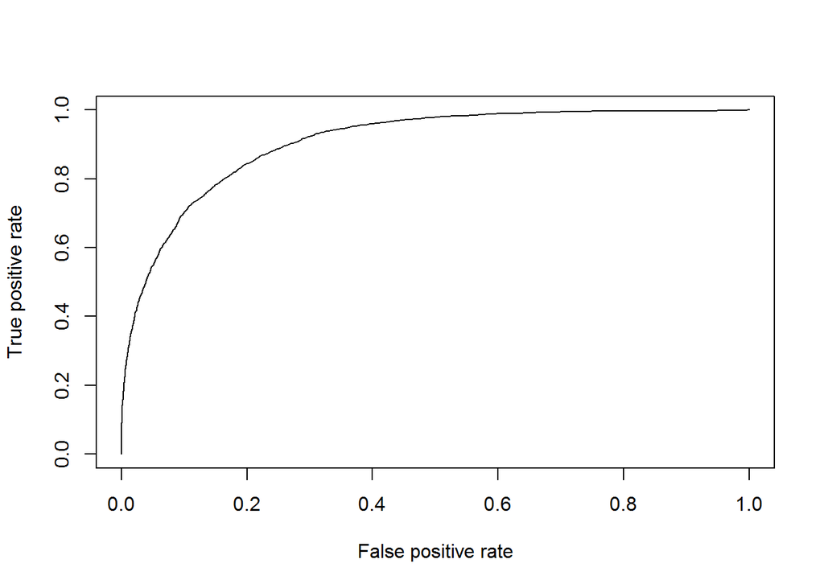

```r
#This was not necessary, but I did it anyway
ROCRperf = performance(ROCRpred, "tpr", "fpr")
plot(ROCRperf)
```

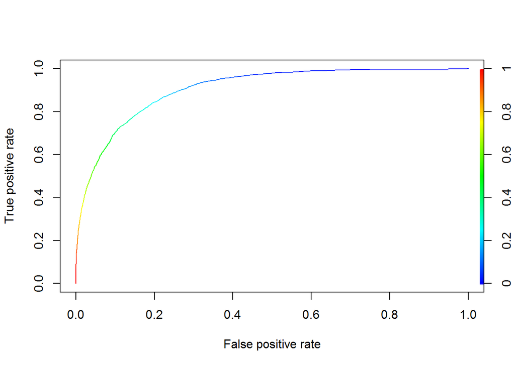

```r
plot(ROCRperf, colorize=TRUE)
```

## Build a CART model

We have just seen how the logistic regression model for this data achieves a high accuracy. Moreover, the significances of the variables give us a way to gauge which variables are relevant for this prediction task. **However, it is not immediately clear which variables are more important than the others**, especially due to the large number of factor variables in this problem.

Let us now build a classification tree to predict “over50k”. Use the training set to build the model, and all of the other variables as independent variables. Use the default parameters, so don’t set a value for minbucket or cp. Remember to specify method=“class” as an argument to rpart, since this is a classification problem. After you are done building the model, plot the resulting tree.

How many splits does the tree have in total?

```r
library(rpart)
```

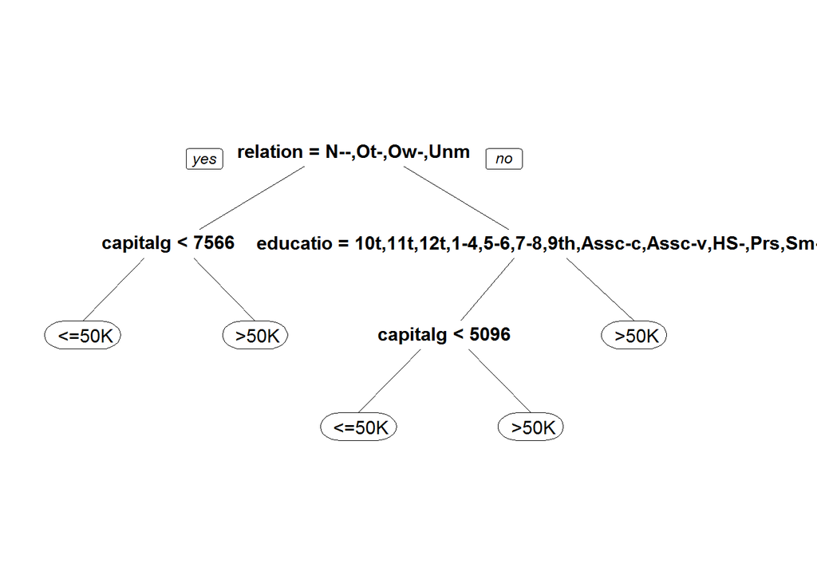

```r
library(rpart.plot)
censustree <- rpart(over50k ~ ., data=train, method="class")
prp(censustree)
```

## Wat is the accuracy of the CART model (i.e. census tree)?

Use a threshold of 0.5. (You can either add the argument type=“class”, or generate probabilities and use a threshold of 0.5 like in logistic regression.)

```r
PredictTree = predict(censustree, newdata = test, type = "class")
t1 <- table(test$over50k, PredictTree)
t1
```

```
##         PredictTree
##           <=50K  >50K
##    <=50K   9243   470
##    >50K    1482  1596
```

```r
accuracy <- sum(diag(t1)/margin.table(t1))
accuracy #0.8473927
```

```
## [1] 0.8473927
```

The other way to calculate accuracy is remove the method = “class” statement and then use a threhold of 0.5 t1 <- table(test$over50k, PredictTree[,2] >= 0.5) t1 accuracy <- sum(diag(t1)/margin.table(t1)) accuracy #0.8473927

This highlights a very regular phenomenon when comparing CART and logistic regression. **CART often performs a little worse** than logistic regression in out-of-sample accuracy. **However**, as is the case here, the CART model **is often much simpler to describe and understand**.

## CART Model: AUC

Let us now consider the ROC curve and AUC for the CART model on the test set. **You will need to get predicted probabilities** for the observations in the test set to build the ROC curve and compute the AUC. Remember that **you can do this by removing the type=“class” argument when making predictions**, and taking the second column of the resulting object.

Plot the ROC curve for the CART model you have estimated. Observe that compared to the logistic regression ROC curve, the CART ROC curve is less smooth than the logistic regression ROC curve. Which of the following explanations for this behavior is most correct? (HINT: Think about what the ROC curve is plotting and what changing the threshold does.)

```r
PredictTest = predict(censustree, newdata = test)
ROCRpred = prediction(PredictTest[ ,2], test$over50k)
auc = as.numeric(performance(ROCRpred, "auc")@y.values)
auc #0.8470256
```

```
## [1] 0.8470256
```

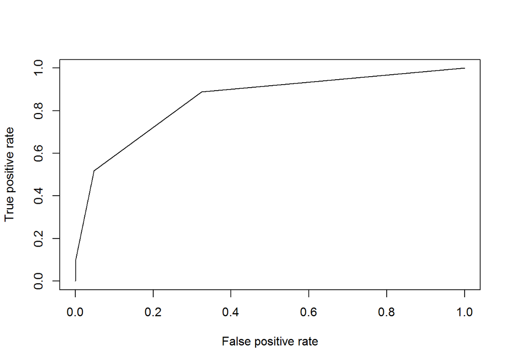

```r
#Plot the ROC curve for the model
ROCRperf = performance(ROCRpred, "tpr", "fpr")
plot(ROCRperf)
```

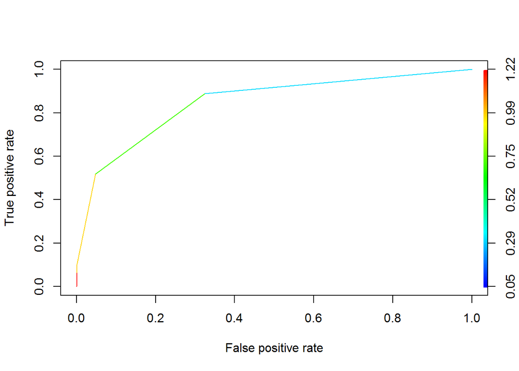

```r
plot(ROCRperf, colorize=TRUE)
```

## Building a Random Forest Model

Before building a random forest model, we’ll down-sample our training set. While some modern personal computers can build a random forest model on the entire training set, others might run out of memory when trying to train the model since random forests is much more computationally intensive than CART or Logistic Regression. For this reason, before continuing we will define a new training set to be used when building our random forest model, that contains 2000 randomly selected obervations from the original training set. Do this by running the following commands in your R console (assuming your training set is called “train”):

```r
set.seed(1)
trainSmall = train[sample(nrow(train), 2000), ]
```

Let us now build a random forest model to predict “over50k”, using the dataset “trainSmall” as the data used to build the model. Set the seed to 1 again right before building the model, and use all of the other variables in the dataset as independent variables. (If you get an error that random forest “can not handle categorical predictors with more than 32 categories”, re-build the model without the nativecountry variable as one of the independent variables.)

Then, make predictions using this model on the entire test set. What is the accuracy of the model on the test set, using a threshold of 0.5? (Remember that you don’t need a “type” argument when making predictions with a random forest model if you want to use a threshold of 0.5. Also, note that your accuracy might be different from the one reported here, since random forest models can still differ depending on your operating system, even when the random seed is set. )

```r
library(randomForest)
set.seed(1)
ForestOver50 = randomForest(over50k ~ . , data = trainSmall)
#Make predictions
ForestPred <- predict(ForestOver50, newdata = test)
t1 <- table(test$over50k, ForestPred)
t1
```

```
##         ForestPred
##           <=50K  >50K
##    <=50K   9555   158
##    >50K    1874  1204
```

```r
accuracy <- sum(diag(t1)/margin.table(t1))
accuracy
```

```
## [1] 0.8411383
```

Random forest models work by building a large collection of trees. As a result, we lose some of the interpretability that comes with CART in terms of seeing how predictions are made and which variables are important. However, we can still compute metrics that give us insight into which variables are important.

### Which vbles are important? -> nº of times used in the forest

One metric that we can look at is the number of times, aggregated over all of the trees in the random forest model, that a certain variable is selected for a split. To view this metric, run the following lines of R code (replace “MODEL” with the name of your random forest model): (IMPORTANT ADD TO THE LESSON SUMMARY) vu = varUsed(MODEL, count=TRUE) vusorted = sort(vu, decreasing = FALSE, index.return = TRUE) dotchart(vusorted$x, names(MODEL$forest$xlevels[vusorted$ix]))

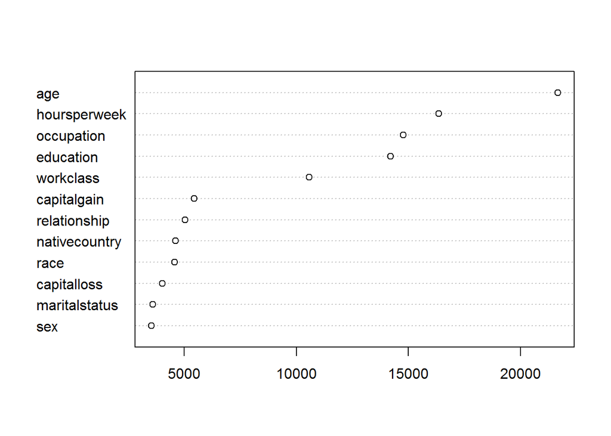

```r
vu = varUsed(ForestOver50, count=TRUE)
vusorted = sort(vu, decreasing = FALSE, index.return = TRUE)
#index.return gives you the position of the variable when it wasn't sorted
dotchart(vusorted$x, names(ForestOver50$forest$xlevels[vusorted$ix]))
```

This code produces a chart that for each variable measures the number of times that variable was selected for splitting (the value on the x-axis).